# Lab3HWPatelDhiraj

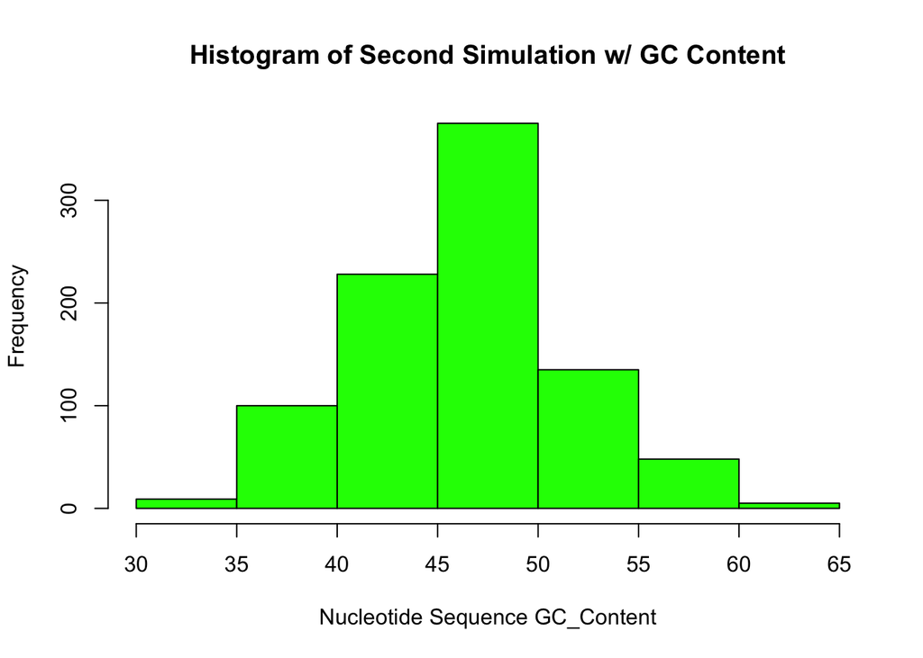

```r
secSim <- funkySampler(dengue_vec,90,900)
hist(secSim,main="Histogram of Second Simulation w/ GC Content",col="green", xlab="Nucleotide Sequence GC_Content")
```

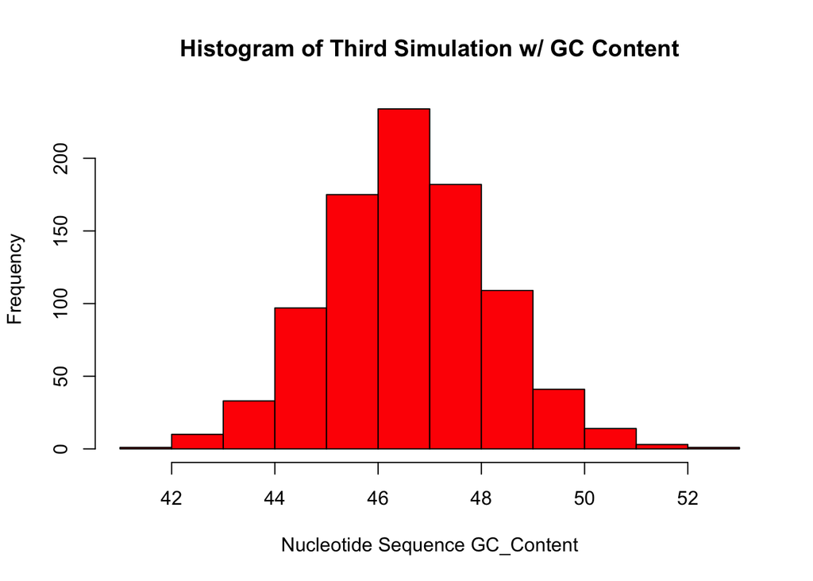

```r
threeSim <- funkySampler(dengue_vec,900,900)
hist(threeSim,main="Histogram of Third Simulation w/ GC Content",col="red", xlab="Nucleotide Sequence GC_Content")
```

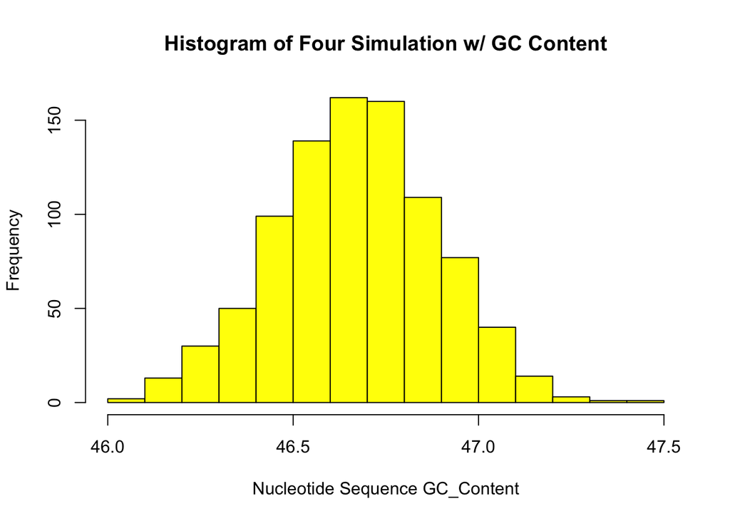

```r
fourSim <- funkySampler(dengue_vec,9000,900)
hist(fourSim,main="Histogram of Four Simulation w/ GC Content",col="yellow", xlab="Nucleotide Sequence GC_Content")
```

```r
#AS THE SAMPLE SIZE CHANGES, THE DISTRIBUTION BECOMES MORE AND MORE SYMMETRIC, AND BASICALLY PERFECTLY SYMMETRIC IN THE LAST HISTOGRAM. Basically, becomes more and more like a normal distribution.
```

(d) For each simulation, how do the means of your samples compare to the GC-content for the dengue DNA sequence as a whole?

5. Read data from the file *MeaslesOutbreaks.csv* into R with the `read.csv()` command. Choose an appropriate variable name for this command. This data comes from Example 2.4A in the Whitlock Schluter textbook.

```r
measlesOutbreakData <- read.csv("MeaslesOutbreaks.csv", header=TRUE,sep=",")
```

(a) Use the `plot()` command you learned in lab to plot a graph using `yearByQuarter` as the explanatory variable and `confirmedCases` as the response variable. Make sure to include axis labels and a title.

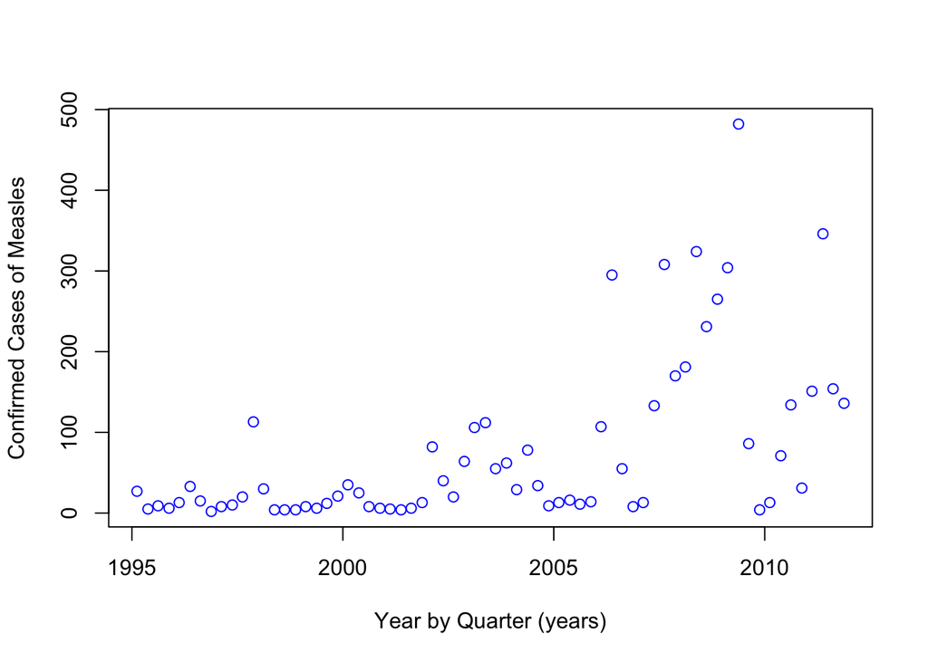

```r
plot(measlesOutbreakData$yearByQuarter,measlesOutbreakData$confirmedCases,ylab="Confirmed Cases of Measles",xlab="Year by Quarter (years)",col="blue")
```

(b) Add the parameter `type="l"` to your `plot()` command from part (a). How does this change your graph?

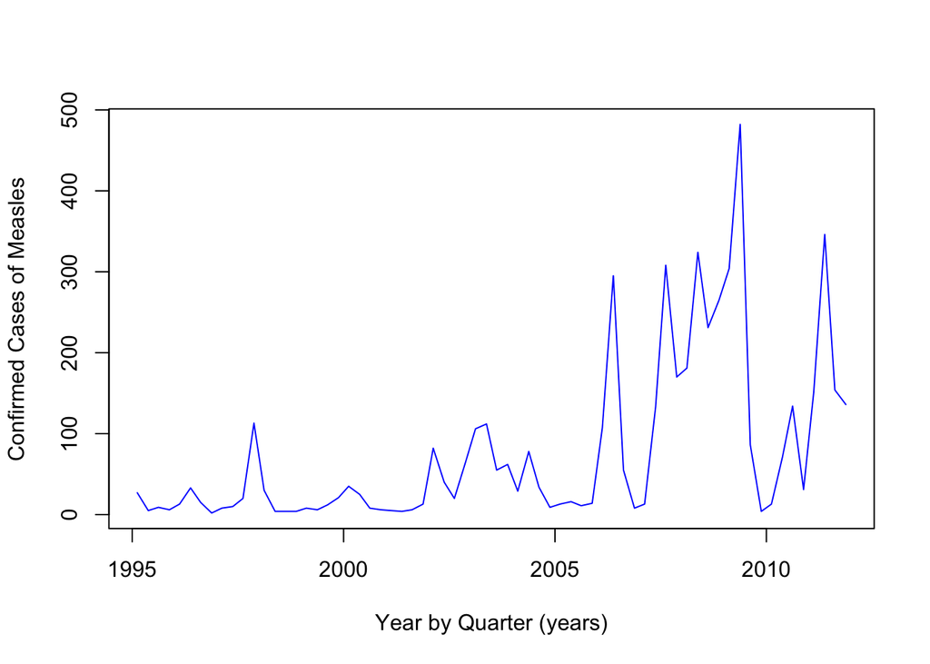

```r
plot(measlesOutbreakData$yearByQuarter,measlesOutbreakData$confirmedCases,ylab="Confirmed Cases of Measles",xlab="Year by Quarter (years)",col="blue",type="l")
```

[figure not shown]

```r
#Adding the type parameter, converts the scatter plot into essentially a line graph, by basically connecting all the dots in the previous plot.
```